# Statistics, Random Numbers and Stochastic Simulation

Richard Upton  
7 August 2015

### Statistics in R

There are plenty of textbooks on this!

Here are the very basics

```r
> statdata <- read.csv("stats_data.csv")
> statdata$AGEBIN <- as.factor(statdata$AGEBIN)
> head(statdata)
```

```
  ID DOSE ROUTE AGE AGEBIN WEIGHT
1  1   50     0  32      0     75
2  2   50     0  79      1     54
3  3   50     0  60      1     90
4  4   50     0  79      1     63
5  5   50     0  25      0     66
6  6   50     1  64      1     68
```

### Statistics - Linear regression

The variables are both continuous

```r
> result1 <- lm(WEIGHT~AGE, data=statdata)
```

### Statistics - Linear regression

```
Call:
lm(formula = WEIGHT ~ AGE, data = statdata)

Residuals:
   Min     1Q Median     3Q    Max
 -9.29  -7.56  -1.47   4.32  22.79

Coefficients:
            Estimate Std. Error t value Pr(>|t|)
(Intercept)   80.039      6.360   12.58  2.3e-10 ***
AGE           -0.214      0.116   -1.85    0.081 .
---
Signif. codes:  0 '***' 0.001 '**' 0.01 '*' 0.05 '.' 0.1 ' ' 1

Residual standard error: 9.16 on 18 degrees of freedom
Multiple R-squared:  0.16,  Adjusted R-squared:  0.113
F-statistic: 3.42 on 1 and 18 DF,  p-value: 0.0808
```

### Statistics - Analysis of Variance 1

Fact: ANOVA is a type of linear regression

The independent variable is a factor

It represented internally by “contrasts” - 0 or 1

```r
> result2 <- lm(WEIGHT~AGEBIN, data=statdata)
```

### Statistics - Analysis of Variance 1

```
Call:
lm(formula = WEIGHT ~ AGEBIN, data = statdata)

Residuals:
   Min     1Q Median     3Q    Max
-14.00  -6.00  -4.29   4.93  22.00

Coefficients:
            Estimate Std. Error t value Pr(>|t|)
(Intercept)    70.57       3.74   18.85  2.7e-13 ***
AGEBIN1        -2.57       4.64   -0.55     0.59
---
Signif. codes:  0 '***' 0.001 '**' 0.01 '*' 0.05 '.' 0.1 ' ' 1

Residual standard error: 9.9 on 18 degrees of freedom
Multiple R-squared:  0.0168,    Adjusted R-squared:  -0.0379
F-statistic: 0.307 on 1 and 18 DF,  p-value: 0.587
```

### Statistics - Analysis of Variance 2

This produces the same result

```r
> result3 <- aov(WEIGHT~AGEBIN, data=statdata)
```

```
            Df Sum Sq Mean Sq F value Pr(>F)
AGEBIN       1     30    30.1    0.31   0.59
Residuals   18   1766    98.1
```

### Statistical output

The statistical output is stored as a list object

Lists can be nested structures of mixed data types

```r
> names(result1)
```

```
 [1] "coefficients"  "residuals"     "effects"       "rank"
 [5] "fitted.values" "assign"        "qr"            "df.residual"
 [9] "xlevels"       "call"          "terms"         "model"
```

```r
> result1$coefficients["AGE"]
```

```
    AGE
-0.2138
```

### Repeated measures data

Use mixed-effect linear regression (lme)

This is analogous to NONMEM with fixed and random effects

```r
> library(nlme)
> #lme(WEIGHT~AGEBIN, random= ~1|ID, data=repdata)
```

[figure not shown]

### Stochastic simulation

The simulation of a system that has random components

Randomness comes from a random number generator

The random numbers can be modified into various distributions

- Normal
- Log-normal
- Uniform
- Bionomial

### Simulation in pharmacometrics

All simulations from population models are stochastic

The stochastic components (ETA, EPS) of the model are recreated by sampling from distributions of random numbers

Examples

- Visual Predictive Check
- Simulations of model prediction intervals
- Clinical trial simulation
- Simulations of study power

### Generating random numbers

Many computer algorithms have been developed

Pseudo-random numbers will eventually repeat

Testing for randomness is complicated

- plot(runif(10000) ~ runif(10000))
- estimate pi

Bad algorithims repeat quickly and may be autocorrelated

- Excel had problems

### Random Number Table

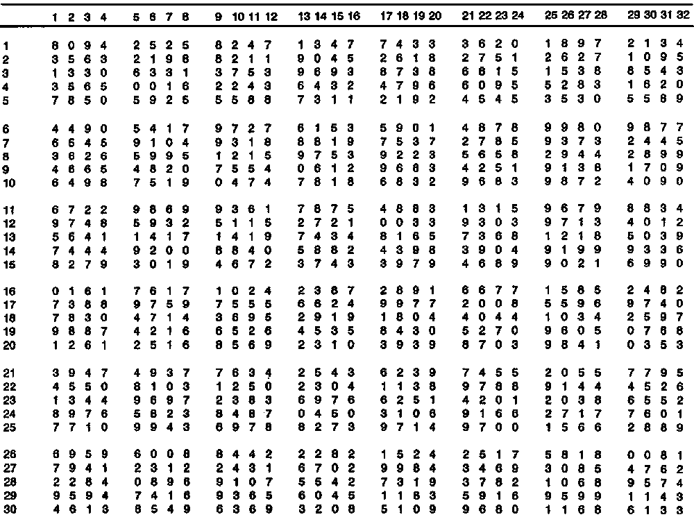

### A test of randomness

x and y are 10,000 independent random uniform numbers

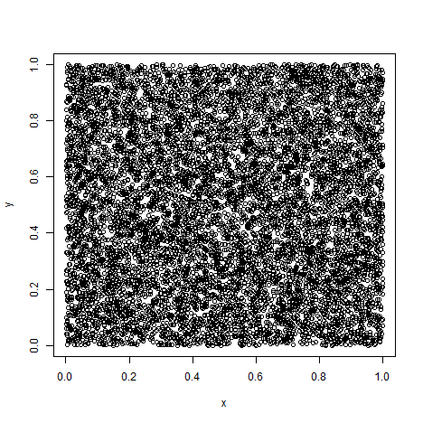

```r
x <- runif(10000)
y <- runif(10000)
plot(y ~ x)
```

### Careful - we see patterns in randomness!

### Why simulate in R rather than NONMEM?

In NONMEM, doses and covariates are coded in the database

If you want to change these in a simulation, you make a new database

If it's complex simulation, this is usually done with R

And R might be used to plot the simulated data anyway

So cut out the middle man and use R for everything!

It may (sometimes!) be faster and easier

### Generating random numbers in R

R has a family of functions for random numbers  
see ?Distributions

| function | distribution | examples |
| --- | --- | --- |
| rnorm | normal | additive residual error, PD baseline |
| rlnorm | log-normal | clearance, distribution volume |
| runif | uniform | age |
| rbinom | binomial | sex, genotype |

### Related functions in R

For each class of distribution

| function | distribution | comment |
| --- | --- | --- |
| dnorm(x, mean=0, sd=1) | gives the density of x | used in maximum likelihood estimation |
| pnorm(x, mean=0, sd=1) | gives the distribution function | turns x into a probability |
| qnorm(p, mean=0, sd=1) | gives the quantile function | turns probability into a quantile |
| rnorm(n, mean=0, sd=1) | generate n random numbers | from a distribution with mean=0 and sd=1 |

### Using the rnorm function

```r
> randomn <- rnorm(n=10, mean=2, sd=0.5)
> randomn
```

```
 [1] 3.230 2.229 2.579 1.762 1.974 1.952 1.454 2.980 2.092 2.219
```

```r
> mean(randomn)
```

```
[1] 2.247
```

```r
> sd(randomn)
```

```
[1] 0.5441
```

### Using the rnorm function

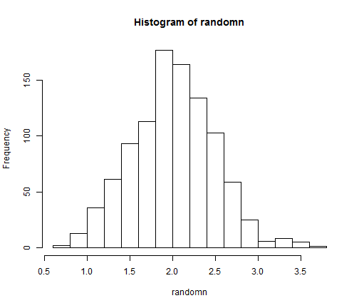

```r
> randomn <- rnorm(n=1000, mean=2, sd=0.5)
> hist(randomn)
```

### Using the rlnorm function

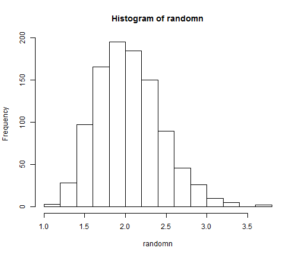

```r
> randomn <- rlnorm(n=1000, mean=log(2), sd=0.2)
> #Note sd is now a ratio
> hist(randomn)
```

### Using the runif function

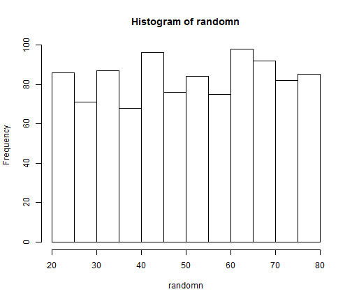

```r
> randomn <- runif(n=1000, min=20, max=80)
> hist(randomn, breaks=10)
```

### Using the rbinom function

```r
> randomn <- rbinom(n=1000, size=1, prob=0.25)
> table(randomn)
```

```
randomn
  0   1
761 239
```

### A simulation to understand randomness

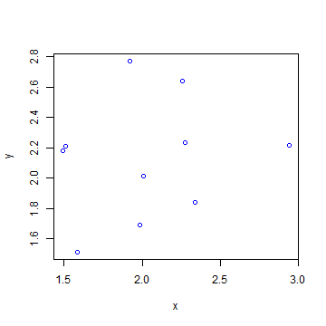

```r
> x <- rlnorm(n=10, mean=log(2), sd=0.2)
> y <- rlnorm(n=10, mean=log(2), sd=0.2)
> plot(y ~ x, col="blue")
```

### We are programmed to see patterns!

Our job as scientists is to distinguish information from randomness

p < 0.05 means we are happy to fooled by randomness 1 time out of 20!

For low powered studies, focus on effect size and uncertainty

p-values are for *confirming* not *learning*

### Setting a seed for reproducible random numbers!

```r
> #No seed set
> rnorm(n=3, mean=2, sd=0.5)
```

```
[1] 2.162 1.952 1.797
```

```r
> #No seed set
> rnorm(n=3, mean=2, sd=0.5)
```

```
[1] 2.218 2.603 1.539
```

### Setting a seed for reproducible random numbers!

```r
> set.seed(123)
> rnorm(n=3, mean=2, sd=0.5)
```

```
[1] 1.720 1.885 2.779
```

```r
> set.seed(123)
> rnorm(n=3, mean=2, sd=0.5)
```

```
[1] 1.720 1.885 2.779
```

### Testing normality - quantile-quantile plots

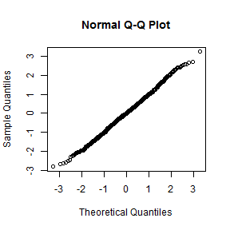

```r
> x <- rnorm(1000)
> qqnorm(x)
```

### Testing normality - quantile-quantile plots

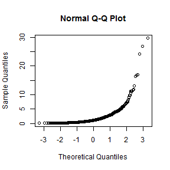

```r
> y <- rlnorm(1000)
> qqnorm(y)
```

### Log-normal distributions in biology

Normal distributions arise from additive process  
**c(mean+1, mean+3, mean+0, mean-2, mean+2)**

Log-normal distributions arise from multiplicative processes  
**c(mean*2, mean/3, mean*1, mean/2, mean*4)**

Log-normal distributions are common in biological systems

No zero values, right skewed, occasional high values

Described by the geometric mean, the standard deviation is a ratio

### Truncated & Censored distributions

A metric may have normal distribution

But our ability to measure the metric might be censored:

- LLOQ of an assay
- Ethical limits for thermal pain tests

The distribution we measure is censored or truncated

This may need to replicated in a model

### Non-normal distributions

Skewed

- Left (median > mean)
- Right (median < mean)

Kurtotic

- Unimodal (median = mean)
- Platykurtic, thin-tailed, peaky
- Leptokurtic, fat-tailed, flat

Multi-modal

- More than 1 peak

### Transformed distributions

NONMEM simulations assume an underlying normal distribution for ETA

A transformation may replicate a skewed parameter distribution

Transformations try to “normalize” a distribution

- Log-normal
- Box-Cox
- Manly

See Petersson et al., *Pharm Res* 2009 26:2174-85

### Additive Between Subject Variability

Effect = Baseline + Slope*Conc

```r
> nsubs <- 1000
> SLOPEpop <- 2
> ETA <- rnorm(nsubs, mean=0, sd=1.5)
> SLOPE <- SLOPEpop + ETA
```

ETA is normally distributed  
SLOPE is normally distributed  
SLOPE can take negative values

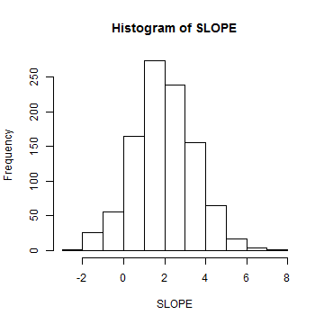

```r
> hist(SLOPE)
```

### Exponential Between Subject Variability

CL = CLpop*exp(ETA)

```r
> nsubs <- 1000
> CLpop <- 2
> ETA <- rnorm(nsubs, mean=0, sd=0.2)
> CL <- CLpop*exp(ETA)
```

### Exponential Between Subject Variability

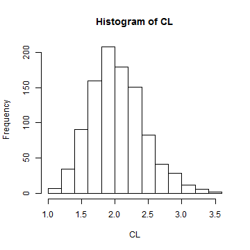

```r
> hist(CL)
```

### Additive Residual Error

Y = F + EPS  
F is model predicted concentration (fake with uniform random numbers!)

```r
> nobs <- 1000
> F <- runif(nobs, min=0, max=10)
> EPS <- rnorm(nobs, mean=0, sd=1.5)
> Y <- F + EPS
```

Y (DV) is F with RUV  
F is never negative  
Y has negative values  
shape = “tram tracks”

### Additive Residual Error

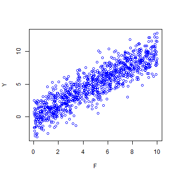

```r
> plot(Y ~ F, col="blue")
```

### Proportional Residual Error

Y = F*(1 + EPS) or Y = F + F*EPS

```r
> nobs <- 1000
> F <- runif(nobs, min=0, max=10)
> EPS <- rnorm(nobs, mean=0, sd=0.1)
> Y <- F*(1 + EPS)
```

Y (DV) is F with RUV  
F is never negative  
Y is never negative  
(unless sd is large!)  
shape = “cone”

### Proportional Residual Error

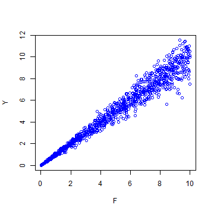

```r
> plot(Y ~ F, col="blue")
```

### Additive and Proportional Residual Error

Y = F*(1 + EPS1) + EPS2

```r
> nobs <- 1000
> F <- runif(nobs, min=0, max=10)
> EPS1 <- rnorm(nobs, mean=0, sd=0.1)
> EPS2 <- rnorm(nobs, mean=0, sd=0.5)
> Y <- F*(1 + EPS1) + EPS2
```

Y (DV) is F with RUV  
F is never negative  
Y can be negative  
(at low concentrations)  
shape = “tramtracks+cone”

### Additive and Proportional Residual Error

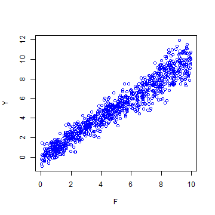

```r
> plot(Y ~ F, col="blue")
```

### How many simulations?

Enough!

Simulations are repeated until the effect of randomness on summary statistics (e.g. mean and CI) are minimal

Some rules of thumb:

- 200 times for a mean
- 1,000 times for a confidence interval
- 10,000 times for study power

Capacity may be limited by computer memory for big problems(64 bit helps)

### Covariance

Covariance is a measure of how much two random variables change together

Not accounting for covariance may mean simulating implausible combinations of random numbers

```r
> HEIGHTcm <- rnorm(1000, mean=170, sd=12)
> WEIGHTkg <- rnorm(1000, mean=70, sd=8)
```

### Without Covariance

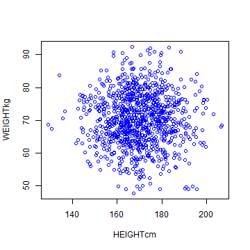

```r
> plot(WEIGHTkg ~ HEIGHTcm, col="blue")
```

### Covariance

Covariance in NONMEM comes from $OMEGA BLOCK

Simulating correlated random numbers is complex

```r
> library(MASS)
> OMEGA <- matrix(c(150,80,40,65),2,2)
> result <- mvrnorm(n=1000, mu=c(170,70), OMEGA)
> HEIGHTcm <- result[,1]
> WEIGHTkg <- result[,2]
```

### With Covariance

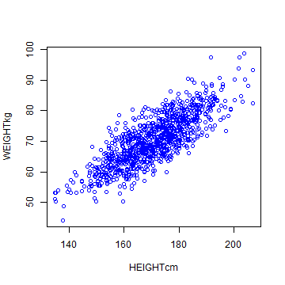

```r
> plot(WEIGHTkg ~ HEIGHTcm, col="blue")
```

### Summary

Generating random numbers shows the influence of randomness on data

- Use simulation to educate yourself about how randomness affects your data

Random numbers are at the heart of every population model

- Use simulation to educate yourself about how randomness affects your model

Study design and study power are moving toward simulation based methods